# Reviwe response 2

Agneesh Barua

25/03/2019

# Phylogenetic model with many zeros

To demonstrate the artificial increase in phylogenetic covariance due to incorporating many zero values we ran our model on a dataset of all the reported toxins, and included measure of two imaginary taits: wingspan and limb length for snakes. Since snakes clearly do not posses neither wings or limbs, the value for these trait are zero for all 52 species.

```r
#Tree
snphylo = read.nexus("/Users/agneesh-barua/Dropbox (OIST)/R Training/VC_project/Final_tree.nex")
is.ultrametric(snphylo)
```

```
## [1] TRUE
```

```r
#data
phydata = read.csv("/Users/agneesh-barua/Dropbox (OIST)/R Training/VC_project/Data csv/New data/Review_test.csv", header = TRUE)
```

| species | TFTx | BPP.CNP | CRISP | CTL | GF | KSPI | LAAO | PLA2 | SVMP | SVSP | OHA | CROT | PDE | NUC | VESP | WAPR | PLB | NP | HYAL | CVF | CYST | QC | AChE | DPP_IV | SARA | limb_len | wing_span | Family |
| --- | --- | --- | --- | --- | --- | --- | --- | --- | --- | --- | --- | --- | --- | --- | --- | --- | --- | --- | --- | --- | --- | --- | --- | --- | --- | --- | --- | --- |
| Boiga_irregularis | 0.67475 | 0.01400 | 0.03835 | 0.02271 | 0.00025 | 0.00100 | 0.00000 | 0.00040 | 0.24854 | 0.00000 | 0.0000 | 0.00000 | 0.00000 | 0.00000 | 0.00000 | 0.00000 | 0.00000 | 0.00000 | 0.00000 | 0.00032 | 0.0000 | 0.00000 | 0.0019 | 0.00000 | 0e+00 | 0 | 0 | Colubridae |
| Dispholidus_typus | 0.06200 | 0.00000 | 0.05400 | 0.00400 | 0.00100 | 0.00150 | 0.00000 | 0.07600 | 0.74640 | 0.05500 | 0.0000 | 0.00000 | 0.00000 | 0.00000 | 0.00000 | 0.00070 | 0.00000 | 0.00000 | 0.00000 | 0.00000 | 0.0000 | 0.00000 | 0.0000 | 0.00000 | 0e+00 | 0 | 0 | Colubridae |
| Hypsiglena_torquata | 0.00070 | 0.07359 | 0.16684 | 0.06176 | 0.00012 | 0.00056 | 0.00000 | 0.00000 | 0.68666 | 0.00000 | 0.0000 | 0.00000 | 0.00002 | 0.00000 | 0.00003 | 0.00006 | 0.00000 | 0.00000 | 0.00000 | 0.00000 | 0.0000 | 0.00000 | 0.0000 | 0.00000 | 0e+00 | 0 | 0 | Colubridae |
| Opheodrys_aestivus | 0.13300 | 0.00000 | 0.00000 | 0.00000 | 0.00000 | 0.22000 | 0.00000 | 0.03600 | 0.00000 | 0.00000 | 0.0000 | 0.00000 | 0.00000 | 0.00000 | 0.00000 | 0.00000 | 0.00000 | 0.00000 | 0.00000 | 0.00000 | 0.0000 | 0.00000 | 0.0000 | 0.00000 | 0e+00 | 0 | 0 | Colubridae |
| Pantherophis_guttatus | 0.01000 | 0.00000 | 0.02200 | 0.00000 | 0.00000 | 0.22200 | 0.00000 | 0.12900 | 0.00000 | 0.00000 | 0.0000 | 0.00000 | 0.00000 | 0.00000 | 0.00000 | 0.00000 | 0.00000 | 0.00000 | 0.00000 | 0.00000 | 0.0000 | 0.00000 | 0.0000 | 0.00000 | 0e+00 | 0 | 0 | Colubridae |
| Phalotris_mertensi | 0.01800 | 0.00140 | 0.00330 | 0.21600 | 0.00040 | 0.43900 | 0.02300 | 0.00000 | 0.22040 | 0.00220 | 0.0027 | 0.01300 | 0.00000 | 0.00060 | 0.00000 | 0.01620 | 0.00480 | 0.00000 | 0.00000 | 0.00000 | 0.0020 | 0.00000 | 0.0000 | 0.00000 | 0e+00 | 0 | 0 | Colubridae |
| Philodryas_olfersii | 0.00000 | 0.22400 | 0.10400 | 0.05800 | 0.00000 | 0.00000 | 0.00000 | 0.00000 | 0.52400 | 0.08900 | 0.0000 | 0.00000 | 0.00000 | 0.00000 | 0.00000 | 0.00000 | 0.00000 | 0.00000 | 0.00000 | 0.00000 | 0.0000 | 0.00000 | 0.0000 | 0.00000 | 0e+00 | 0 | 0 | Colubridae |
| Thamnodynastes_strigatus | 0.00200 | 0.00000 | 0.01900 | 0.05400 | 0.00000 | 0.00000 | 0.00000 | 0.00000 | 0.84400 | 0.00700 | 0.0000 | 0.02800 | 0.00000 | 0.00000 | 0.00000 | 0.00000 | 0.00000 | 0.00000 | 0.00400 | 0.00000 | 0.0000 | 0.00000 | 0.0000 | 0.00000 | 0e+00 | 0 | 0 | Colubridae |
| Bungarus_flaviceps | 0.39290 | 0.00000 | 0.00440 | 0.00440 | 0.00000 | 0.24060 | 0.00000 | 0.35320 | 0.00000 | 0.00000 | 0.0000 | 0.00000 | 0.00000 | 0.00000 | 0.00000 | 0.00000 | 0.00000 | 0.00000 | 0.00000 | 0.00000 | 0.0000 | 0.00000 | 0.0000 | 0.00000 | 0e+00 | 0 | 0 | Elapidae |
| Bungarus_multicinctus | 0.64700 | 0.00000 | 0.00700 | 0.03800 | 0.00200 | 0.10600 | 0.00100 | 0.17400 | 0.00000 | 0.00100 | 0.0230 | 0.00040 | 0.00080 | 0.00100 | 0.00000 | 0.00000 | 0.00000 | 0.00000 | 0.00010 | 0.00000 | 0.0000 | 0.00100 | 0.0000 | 0.00000 | 0e+00 | 0 | 0 | Elapidae |
| Drysdalia_coronoides | 0.86000 | 0.00000 | 0.02800 | 0.00000 | 0.01400 | 0.00000 | 0.00000 | 0.00240 | 0.00000 | 0.09200 | 0.0330 | 0.00020 | 0.00600 | 0.00700 | 0.00000 | 0.00000 | 0.00000 | 0.00000 | 0.00030 | 0.00000 | 0.0000 | 0.00020 | 0.0000 | 0.00000 | 0e+00 | 0 | 0 | Elapidae |
| Micrurus_altirostris | 0.86400 | 0.00000 | 0.00000 | 0.01300 | 0.00000 | 0.03800 | 0.00000 | 0.04900 | 0.00600 | 0.00000 | 0.1160 | 0.00000 | 0.00060 | 0.00170 | 0.00000 | 0.00000 | 0.00000 | 0.00000 | 0.00170 | 0.00030 | 0.0000 | 0.00000 | 0.0000 | 0.00000 | 0e+00 | 0 | 0 | Elapidae |
| Micrurus_corallinus | 0.20300 | 0.29530 | 0.00000 | 0.06700 | 0.01830 | 0.00150 | 0.00840 | 0.37680 | 0.02100 | 0.00100 | 0.0000 | 0.00000 | 0.00000 | 0.00000 | 0.00000 | 0.00000 | 0.00000 | 0.00000 | 0.00000 | 0.00000 | 0.0000 | 0.00000 | 0.0000 | 0.00000 | 0e+00 | 0 | 0 | Elapidae |
| Micrurus_fulvius | 0.25160 | 0.00000 | 0.00000 | 0.00799 | 0.01600 | 0.02154 | 0.00880 | 0.64947 | 0.02947 | 0.00000 | 0.0280 | 0.00030 | 0.00200 | 0.00700 | 0.00000 | 0.00090 | 0.00400 | 0.00000 | 0.00020 | 0.00006 | 0.0000 | 0.00000 | 0.0000 | 0.00000 | 6e-05 | 0 | 0 | Elapidae |
| Micrurus_lemniscatus | 0.67220 | 0.00200 | 0.00240 | 0.00480 | 0.01420 | 0.07150 | 0.00730 | 0.17200 | 0.01120 | 0.00100 | 0.0000 | 0.00000 | 0.00000 | 0.00000 | 0.00000 | 0.00000 | 0.00000 | 0.00000 | 0.00000 | 0.00000 | 0.0000 | 0.00000 | 0.0000 | 0.00000 | 0e+00 | 0 | 0 | Elapidae |
| Micrurus_spixii | 0.62640 | 0.00000 | 0.00000 | 0.00000 | 0.00000 | 0.00000 | 0.00000 | 0.36390 | 0.00000 | 0.00000 | 0.0000 | 0.00000 | 0.03000 | 0.00000 | 0.00000 | 0.06000 | 0.00000 | 0.00000 | 0.00000 | 0.00000 | 0.0000 | 0.00000 | 0.0000 | 0.00000 | 0e+00 | 0 | 0 | Elapidae |
| Micrurus_surinamensis | 0.60240 | 0.02670 | 0.00000 | 0.00340 | 0.07880 | 0.01070 | 0.00000 | 0.26230 | 0.00140 | 0.00000 | 0.0000 | 0.00000 | 0.00000 | 0.00000 | 0.00000 | 0.00000 | 0.00000 | 0.00000 | 0.00000 | 0.00000 | 0.0000 | 0.00000 | 0.0000 | 0.00000 | 0e+00 | 0 | 0 | Elapidae |
| Naja_atra | 0.95800 | 0.00000 | 0.00700 | 0.00600 | 0.00100 | 0.00100 | 0.00100 | 0.01200 | 0.00400 | 0.00000 | 0.0000 | 0.00000 | 0.00300 | 0.00300 | 0.00000 | 0.00000 | 0.00300 | 0.00000 | 0.00000 | 0.00000 | 0.0000 | 0.00300 | 0.0000 | 0.00000 | 0e+00 | 0 | 0 | Elapidae |
| Naja_kaouthia | 0.82000 | 0.00000 | 0.00000 | 0.00500 | 0.00300 | 0.00100 | 0.00200 | 0.13600 | 0.01100 | 0.00000 | 0.0000 | 0.00000 | 0.00000 | 0.00000 | 0.00000 | 0.00000 | 0.00000 | 0.00000 | 0.00000 | 0.00000 | 0.0000 | 0.00000 | 0.0000 | 0.00000 | 0e+00 | 0 | 0 | Elapidae |
| Ophiophagus_hannah | 0.43000 | 0.00000 | 0.08700 | 0.00000 | 0.00800 | 0.01000 | 0.05700 | 0.04000 | 0.24400 | 0.00700 | 0.0000 | 0.00060 | 0.05780 | 0.01270 | 0.00000 | 0.00250 | 0.00000 | 0.00000 | 0.00510 | 0.00250 | 0.0019 | 0.00000 | 0.0000 | 0.00000 | 0e+00 | 0 | 0 | Elapidae |
| Pseudonaja_textilis | 0.10633 | 0.00000 | 0.03846 | 0.00000 | 0.00452 | 0.01810 | 0.00000 | 0.18778 | 0.00000 | 0.42534 | 0.0036 | 0.00000 | 0.00000 | 0.00360 | 0.00000 | 0.00000 | 0.00000 | 0.00000 | 0.00360 | 0.00000 | 0.0000 | 0.00000 | 0.0000 | 0.00000 | 0e+00 | 0 | 0 | Elapidae |
| Agkistrodon_piscivorus | 0.00000 | 0.04570 | 0.00000 | 0.06080 | 0.00000 | 0.00000 | 0.00000 | 0.38960 | 0.34900 | 0.08300 | 0.0200 | 0.00020 | 0.00100 | 0.00700 | 0.00000 | 0.00000 | 0.00000 | 0.00000 | 0.00040 | 0.00010 | 0.0000 | 0.00300 | 0.0000 | 0.00000 | 0e+00 | 0 | 0 | Viperidae |
| Atropoides_picadoi | 0.00400 | 0.16400 | 0.02600 | 0.04800 | 0.00600 | 0.00010 | 0.03100 | 0.02300 | 0.56100 | 0.10900 | 0.0000 | 0.16700 | 0.00175 | 0.00327 | 0.00483 | 0.00002 | 0.00000 | 0.00269 | 0.00081 | 0.00005 | 0.0000 | 0.00010 | 0.0000 | 0.00000 | 0e+00 | 0 | 0 | Viperidae |
| Bothriechis_lateralis | 0.01600 | 0.23600 | 0.03200 | 0.03100 | 0.01800 | 0.00020 | 0.03400 | 0.03000 | 0.44900 | 0.10400 | 0.0000 | 0.00000 | 0.00000 | 0.00000 | 0.00000 | 0.00000 | 0.00000 | 0.00000 | 0.00000 | 0.00000 | 0.0000 | 0.00000 | 0.0000 | 0.00000 | 0e+00 | 0 | 0 | Viperidae |
| Bothriechis_schlegelii | 0.03600 | 0.15300 | 0.03600 | 0.00200 | 0.04900 | 0.00120 | 0.03200 | 0.09200 | 0.26300 | 0.20500 | 0.0000 | 0.00195 | 0.00275 | 0.00200 | 0.00640 | 0.00000 | 0.00000 | 0.00200 | 0.00090 | 0.00005 | 0.0000 | 0.00050 | 0.0000 | 0.00000 | 0e+00 | 0 | 0 | Viperidae |
| Bothrops_alternatus | 0.00000 | 0.11800 | 0.02200 | 0.16500 | 0.02500 | 0.00000 | 0.01800 | 0.01400 | 0.58500 | 0.05100 | 0.1500 | 0.00030 | 0.00200 | 0.00200 | 0.00000 | 0.00000 | 0.00000 | 0.00000 | 0.00200 | 0.00006 | 0.0000 | 0.00400 | 0.0000 | 0.00000 | 7e-04 | 0 | 0 | Viperidae |
| Bothrops_asper | 0.00800 | 0.15000 | 0.00800 | 0.01000 | 0.00000 | 0.00030 | 0.04200 | 0.17800 | 0.41600 | 0.13400 | 0.0000 | 0.14843 | 0.00030 | 0.00000 | 0.00183 | 0.00000 | 0.00057 | 0.00000 | 0.00049 | 0.00000 | 0.0000 | 0.00000 | 0.0000 | 0.00000 | 0e+00 | 0 | 0 | Viperidae |
| Bothrops_atrox | 0.00000 | 0.07100 | 0.00500 | 0.04800 | 0.01000 | 0.00000 | 0.01400 | 0.14600 | 0.61600 | 0.08200 | 0.0000 | 0.00000 | 0.07300 | 0.00000 | 0.00000 | 0.00000 | 0.02400 | 0.00000 | 0.02400 | 0.00000 | 0.0000 | 0.00000 | 0.0000 | 0.00000 | 0e+00 | 0 | 0 | Viperidae |
| Bothrops_colombiensis | 0.00000 | 0.01000 | 0.02000 | 0.04000 | 0.02000 | 0.00000 | 0.02000 | 0.30000 | 0.37000 | 0.12000 | 0.0070 | 0.00000 | 0.00000 | 0.00000 | 0.00000 | 0.00000 | 0.00000 | 0.00000 | 0.00000 | 0.00000 | 0.0000 | 0.00000 | 0.0000 | 0.00200 | 0e+00 | 0 | 0 | Viperidae |
| Bothrops_insularis | 0.00000 | 0.15800 | 0.01500 | 0.14200 | 0.05100 | 0.00000 | 0.03500 | 0.05400 | 0.43200 | 0.11200 | 0.0000 | 0.00000 | 0.00000 | 0.00000 | 0.00000 | 0.00000 | 0.00149 | 0.00000 | 0.00000 | 0.00000 | 0.0000 | 0.00000 | 0.0000 | 0.00005 | 0e+00 | 0 | 0 | Viperidae |
| Bothrops_jararaca | 0.00000 | 0.04250 | 0.00400 | 0.13650 | 0.02900 | 0.00200 | 0.04050 | 0.03600 | 0.43600 | 0.26100 | 0.0000 | 0.00000 | 0.00100 | 0.00100 | 0.00000 | 0.00000 | 0.00200 | 0.00000 | 0.00000 | 0.00000 | 0.0000 | 0.00000 | 0.0000 | 0.00000 | 0e+00 | 0 | 0 | Viperidae |
| Bothrops_jararacussu | 0.00000 | 0.01695 | 0.03390 | 0.08475 | 0.00000 | 0.00000 | 0.01695 | 0.56290 | 0.25820 | 0.01695 | 0.0000 | 0.00000 | 0.00000 | 0.00074 | 0.00000 | 0.00000 | 0.00970 | 0.00000 | 0.00009 | 0.00000 | 0.0000 | 0.00064 | 0.0000 | 0.00000 | 0e+00 | 0 | 0 | Viperidae |
| Bothrops_moojeni | 0.00060 | 0.00950 | 0.00570 | 0.02670 | 0.00000 | 0.00440 | 0.01270 | 0.09020 | 0.46630 | 0.26180 | 0.0000 | 0.00000 | 0.00197 | 0.00158 | 0.00000 | 0.00000 | 0.00139 | 0.00000 | 0.00000 | 0.00000 | 0.0000 | 0.00015 | 0.0000 | 0.00000 | 0e+00 | 0 | 0 | Viperidae |
| Bothrops_neuwiedi | 0.00000 | 0.17400 | 0.00700 | 0.08600 | 0.00360 | 0.00000 | 0.02900 | 0.26400 | 0.36000 | 0.05300 | 0.0000 | 0.00000 | 0.00280 | 0.00000 | 0.00000 | 0.00000 | 0.00000 | 0.00000 | 0.00000 | 0.00000 | 0.0000 | 0.00000 | 0.0000 | 0.00000 | 0e+00 | 0 | 0 | Viperidae |
| Cerrophidion_godmani | 0.00600 | 0.08300 | 0.02600 | 0.00200 | 0.00600 | 0.00000 | 0.05500 | 0.07900 | 0.42200 | 0.28100 | 0.0000 | 0.00000 | 0.00000 | 0.00000 | 0.00000 | 0.00000 | 0.00000 | 0.00440 | 0.00000 | 0.00000 | 0.0000 | 0.00000 | 0.0000 | 0.00000 | 0e+00 | 0 | 0 | Viperidae |
| Crotalus_adamanteus | 0.00000 | 0.00726 | 0.01317 | 0.22155 | 0.00023 | 0.00054 | 0.05309 | 0.07810 | 0.24410 | 0.19979 | 0.0000 | 0.00000 | 0.00000 | 0.00000 | 0.00400 | 0.00000 | 0.00000 | 0.01300 | 0.00000 | 0.00000 | 0.0000 | 0.00000 | 0.0010 | 0.00000 | 0e+00 | 0 | 0 | Viperidae |
| Crotalus_durissus | 0.00000 | 0.00000 | 0.00000 | 0.00000 | 0.04000 | 0.00000 | 0.00000 | 0.88000 | 0.03000 | 0.02500 | 0.0000 | 0.00000 | 0.00000 | 0.00000 | 0.00000 | 0.00000 | 0.00700 | 0.00000 | 0.00000 | 0.00000 | 0.0000 | 0.00000 | 0.0000 | 0.00000 | 0e+00 | 0 | 0 | Viperidae |
| Crotalus_horridus | 0.00000 | 0.12519 | 0.00775 | 0.00213 | 0.02285 | 0.00119 | 0.01106 | 0.22772 | 0.00111 | 0.58229 | 0.0020 | 0.00000 | 0.00000 | 0.00000 | 0.00000 | 0.00200 | 0.00000 | 0.01900 | 0.00000 | 0.00000 | 0.0000 | 0.00000 | 0.0000 | 0.00000 | 0e+00 | 0 | 0 | Viperidae |
| Crotalus_simus | 0.12700 | 0.13400 | 0.00000 | 0.02400 | 0.00000 | 0.00150 | 0.03800 | 0.12100 | 0.06500 | 0.28100 | 0.0000 | 0.00000 | 0.00000 | 0.00000 | 0.00000 | 0.00300 | 0.00500 | 0.00000 | 0.00000 | 0.00000 | 0.0000 | 0.00000 | 0.0000 | 0.00000 | 0e+00 | 0 | 0 | Viperidae |
| Crotalus_scutulatus | 0.00000 | 0.20121 | 0.00481 | 0.16943 | 0.02000 | 0.00021 | 0.00925 | 0.18171 | 0.14363 | 0.11692 | 0.0000 | 0.00000 | 0.00110 | 0.00220 | 0.00000 | 0.00000 | 0.00330 | 0.00700 | 0.00000 | 0.00000 | 0.0000 | 0.00000 | 0.0000 | 0.00000 | 0e+00 | 0 | 0 | Viperidae |
| Gloydius_intermedius | 0.00000 | 0.04900 | 0.04900 | 0.04900 | 0.14600 | 0.00000 | 0.02400 | 0.12200 | 0.17000 | 0.22000 | 0.0166 | 0.00000 | 0.00000 | 0.00000 | 0.01660 | 0.00450 | 0.00130 | 0.00000 | 0.00000 | 0.00000 | 0.0000 | 0.00000 | 0.0000 | 0.00000 | 0e+00 | 0 | 0 | Viperidae |
| Lachesis_muta | 0.01600 | 0.73200 | 0.00000 | 0.05800 | 0.00300 | 0.00000 | 0.03700 | 0.04700 | 0.05900 | 0.03500 | 0.0024 | 0.00000 | 0.00000 | 0.00000 | 0.00240 | 0.00000 | 0.00180 | 0.00000 | 0.00000 | 0.00000 | 0.0000 | 0.00000 | 0.0000 | 0.00000 | 0e+00 | 0 | 0 | Viperidae |
| Ovophis_okinavensis | 0.00000 | 0.00000 | 0.00000 | 0.00579 | 0.00008 | 0.00000 | 0.00623 | 0.00647 | 0.04220 | 0.86176 | 0.0000 | 0.00000 | 0.00000 | 0.00000 | 0.00000 | 0.00000 | 0.00000 | 0.00000 | 0.00270 | 0.00000 | 0.0000 | 0.00000 | 0.0000 | 0.00000 | 0e+00 | 0 | 0 | Viperidae |
| Protobothrops_elegans | 0.00000 | 0.01400 | 0.00001 | 0.00200 | 0.00600 | 0.00000 | 0.00500 | 0.77100 | 0.08100 | 0.10400 | 0.0000 | 0.00000 | 0.00000 | 0.00000 | 0.00500 | 0.00000 | 0.00000 | 0.00000 | 0.00000 | 0.00000 | 0.0020 | 0.00000 | 0.0000 | 0.00000 | 0e+00 | 0 | 0 | Viperidae |
| Protobothrops_mucrosquamatus | 0.00000 | 0.00000 | 0.01018 | 0.01018 | 0.00647 | 0.00000 | 0.01200 | 0.25746 | 0.39966 | 0.28076 | 0.0090 | 0.00000 | 0.00100 | 0.00100 | 0.00000 | 0.00000 | 0.00100 | 0.00000 | 0.00040 | 0.00200 | 0.0020 | 0.00000 | 0.0003 | 0.00000 | 0e+00 | 0 | 0 | Viperidae |
| Protobothrops_flavoviridis | 0.00000 | 0.00000 | 0.03854 | 0.15356 | 0.00960 | 0.00000 | 0.09071 | 0.32136 | 0.26975 | 0.11054 | 0.0000 | 0.00000 | 0.01100 | 0.00400 | 0.05700 | 0.00000 | 0.00200 | 0.00000 | 0.00000 | 0.02800 | 0.0060 | 0.00000 | 0.0010 | 0.00000 | 0e+00 | 0 | 0 | Viperidae |
| Sistrurus_catenatus | 0.00830 | 0.00280 | 0.06670 | 0.01390 | 0.06670 | 0.00000 | 0.03610 | 0.28060 | 0.12220 | 0.37500 | 0.0000 | 0.00000 | 0.00000 | 0.00000 | 0.00000 | 0.00000 | 0.00226 | 0.02489 | 0.00452 | 0.00000 | 0.0000 | 0.00000 | 0.0000 | 0.00000 | 0e+00 | 0 | 0 | Viperidae |
| Bitis_gabonica | 0.00000 | 0.01813 | 0.00000 | 0.07591 | 0.03626 | 0.09064 | 0.05665 | 0.05665 | 0.37729 | 0.14729 | 0.0000 | 0.00000 | 0.00000 | 0.13369 | 0.00000 | 0.00000 | 0.00000 | 0.00000 | 0.00000 | 0.00000 | 0.0000 | 0.00000 | 0.0000 | 0.00000 | 0e+00 | 0 | 0 | Viperidae |
| Echis_carinatus | 0.00000 | 0.00000 | 0.01934 | 0.17602 | 0.00580 | 0.00193 | 0.01161 | 0.08317 | 0.64603 | 0.04836 | 0.0000 | 0.00000 | 0.00387 | 0.00193 | 0.00000 | 0.00000 | 0.00000 | 0.00000 | 0.00193 | 0.00000 | 0.0000 | 0.00000 | 0.0000 | 0.00000 | 0e+00 | 0 | 0 | Viperidae |
| Echis_coloratus | 0.00000 | 0.00000 | 0.05426 | 0.10543 | 0.00620 | 0.00000 | 0.04031 | 0.05426 | 0.68527 | 0.04496 | 0.0000 | 0.00000 | 0.00300 | 0.00465 | 0.00000 | 0.00000 | 0.00000 | 0.00000 | 0.00000 | 0.00000 | 0.0000 | 0.00000 | 0.0000 | 0.00150 | 0e+00 | 0 | 0 | Viperidae |
| Echis_ocellatus | 0.00000 | 0.00000 | 0.00297 | 0.10979 | 0.02671 | 0.00193 | 0.01187 | 0.08605 | 0.73591 | 0.02374 | 0.0000 | 0.00000 | 0.00000 | 0.00000 | 0.00000 | 0.00000 | 0.00000 | 0.00000 | 0.00154 | 0.00000 | 0.0000 | 0.00000 | 0.0000 | 0.00000 | 0e+00 | 0 | 0 | Viperidae |
| Echis_pyramidum | 0.00000 | 0.00000 | 0.00000 | 0.24011 | 0.00582 | 0.00000 | 0.02639 | 0.20580 | 0.50000 | 0.01979 | 0.0000 | 0.00000 | 0.00000 | 0.00200 | 0.00000 | 0.00000 | 0.00000 | 0.00000 | 0.00000 | 0.00000 | 0.0000 | 0.00000 | 0.0000 | 0.00000 | 0e+00 | 0 | 0 | Viperidae |

```r
#normalize libraries
phydata.norm <- phydata
phydata.norm[,2:28] <- t(scale(t(phydata.norm[,2:28])))
```

The model:

```r
inv.phylo = inverseA(snphylo, nodes = "TIPS", scale =TRUE)

priors1 <- list(G=list(G1=list(V=diag(27), nu=0.002)), R=list(V=diag(27), nu= 0.002)) # standard prior
ptm <- proc.time()



cov_model.toy<-MCMCglmm(cbind(TFTx,BPP.CNP,CRISP,CTL,GF,KSPI,LAAO,PLA2,SVMP,SVSP,OHA,CROT,PDE,NUC,VESP,WAPR,PLB,NP,HYAL,CVF,CYST,QC,AChE,DPP_IV,SARA,limb_len,wing_span) ~ trait-1,
                      random = ~us(trait):species,
                      rcov = ~us(trait):units,
                      family=c(rep("gaussian",27)),
                      ginverse=list(species=inv.phylo$Ainv),
                      prior=priors1,
                      data=phydata.norm,
                      nitt=100000, burnin=30000, thin=500, pr = TRUE)
```

```r
summary(cov_model.toy)
```

```
##
##  Iterations = 30001:99501
##  Thinning interval  = 500
##  Sample size  = 140
##
##  DIC: -6457.951
##
##  G-structure:  ~us(trait):species
##
##                                        post.mean   l-95% CI u-95% CI
## traitTFTx:traitTFTx.species            5.4410884  2.730e+00  8.94911
## traitBPP.CNP:traitTFTx.species        -0.4911189 -2.773e+00  1.71683
## traitCRISP:traitTFTx.species          -0.1548826 -7.473e-01  0.37040
## traitCTL:traitTFTx.species            -0.8088055 -3.092e+00  0.77852
## traitGF:traitTFTx.species              0.0169062 -9.286e-01  0.97604
## traitKSPI:traitTFTx.species           -0.4953967 -2.650e+00  1.41145
## traitLAAO:traitTFTx.species           -0.0272801 -3.703e-01  0.37229
## traitPLA2:traitTFTx.species           -0.4418916 -3.113e+00  2.26915
## traitSVMP:traitTFTx.species           -2.9524626 -7.723e+00  0.25625
## traitSVSP:traitTFTx.species           -1.2931880 -3.979e+00  1.43291
## traitOHA:traitTFTx.species             0.1596234 -3.672e-01  0.67043
## traitCROT:traitTFTx.species           -0.0179143 -7.913e-01  0.88216
## traitPDE:traitTFTx.species             0.1125053 -1.770e-01  0.49777
## traitNUC:traitTFTx.species             0.0418904 -3.996e-01  0.46704
## traitVESP:traitTFTx.species            0.0501471 -1.899e-01  0.36330
## traitWAPR:traitTFTx.species            0.0848978 -1.628e-01  0.27373
## traitPLB:traitTFTx.species             0.0751661 -8.263e-02  0.23877
## traitNP:traitTFTx.species              0.0530325 -1.497e-01  0.28847
## traitHYAL:traitTFTx.species            0.0642012 -8.855e-02  0.27270
## traitCVF:traitTFTx.species             0.0673117 -1.917e-01  0.21960
## traitCYST:traitTFTx.species            0.0713250 -1.196e-01  0.21449
## traitQC:traitTFTx.species              0.0793904 -8.943e-02  0.24765
## traitAChE:traitTFTx.species            0.0769272 -1.090e-01  0.24359
## traitDPP_IV:traitTFTx.species          0.0723948 -7.905e-02  0.29262
## traitSARA:traitTFTx.species            0.0737410 -1.188e-01  0.22819
## traitlimb_len:traitTFTx.species        0.0733759 -1.022e-01  0.23450
## traitwing_span:traitTFTx.species       0.0742604 -1.250e-01  0.23620
## traitTFTx:traitBPP.CNP.species        -0.4911189 -2.773e+00  1.71683
## traitBPP.CNP:traitBPP.CNP.species      2.4975957  1.118e-01  6.73530
## traitCRISP:traitBPP.CNP.species        0.0422371 -4.572e-01  0.76895
```

[output cut: 2910 more lines]

```
## traitVESP       -0.30834 -0.44653 -0.14101   140.00 <0.007 **
## traitWAPR       -0.30205 -0.46562 -0.13530   140.00 <0.007 **
## traitPLB        -0.31111 -0.44237 -0.17793   140.00 <0.007 **
## traitNP         -0.31485 -0.46144 -0.20319   140.00 <0.007 **
## traitHYAL       -0.31395 -0.44714 -0.21241   140.00 <0.007 **
## traitCVF        -0.31543 -0.46490 -0.22424   178.75 <0.007 **
## traitCYST       -0.31640 -0.43117 -0.18238   140.00 <0.007 **
## traitQC         -0.31542 -0.42363 -0.18501   140.00 <0.007 **
## traitAChE       -0.31808 -0.44143 -0.20616   140.00 <0.007 **
## traitDPP_IV     -0.31735 -0.43872 -0.21215   140.00 <0.007 **
## traitSARA       -0.31894 -0.44183 -0.19864   140.00 <0.007 **
## traitlimb_len   -0.31723 -0.43060 -0.20409   140.00 <0.007 **
## traitwing_span  -0.31814 -0.43561 -0.20114   140.00 <0.007 **
## ---
## Signif. codes:  0 '***' 0.001 '**' 0.01 '*' 0.05 '.' 0.1 ' ' 1
```

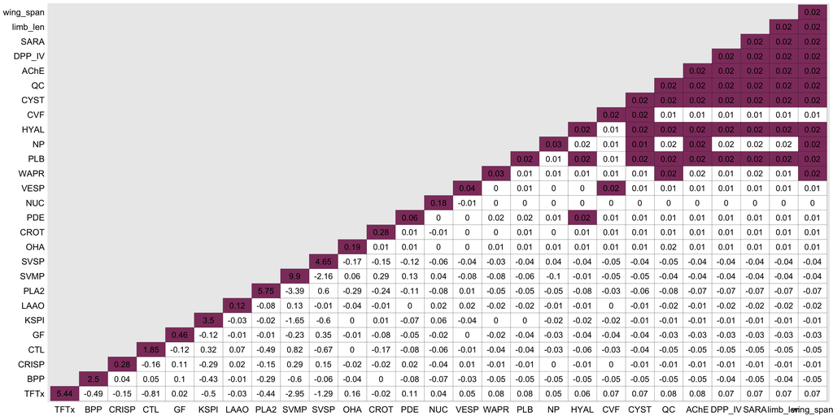

```r
plot(ggheatmap+custom_theme+text)
```

# Surface Analysis

We carried out surface analysis for 25 toxins. We used the first two principal components as input. Since we could not carry out phylogenetic modelling with so many missing traits the principal components used here are not phylogentically corrected and potentially has several analytical caveats. We none the less carried out the analysis to check whether we get any significant result.

```r
phydata$limb_len<-NULL
phydata$wing_span<-NULL
all_comps<-cov(phydata.norm[,2:26])
```

## Determine principal components for 25 toxins

```r
Eig<-eigen(all_comps)
evectors <- Eig$vectors
rownames(evectors) <- colnames(phydata.norm)[2:26]


#Variation explained by individual components
print(round(Eig$values/sum(Eig$values) * 100, digits = 2))
```

```
##  [1] 44.43 20.36 13.35  8.40  7.28  2.59  1.18  0.78  0.45  0.39  0.32
## [12]  0.18  0.15  0.07  0.03  0.02  0.01  0.00  0.00  0.00  0.00  0.00
## [23]  0.00  0.00  0.00
```

```r
#Cummilative Variation explained by individual components
print(round(cumsum(Eig$values)/sum(Eig$values) * 100, digits = 2))
```

```
##  [1]  44.43  64.79  78.14  86.54  93.82  96.42  97.60  98.38  98.83  99.23
## [11]  99.54  99.72  99.87  99.94  99.97  99.99 100.00 100.00 100.00 100.00
## [21] 100.00 100.00 100.00 100.00 100.00
```

```r
scores <- as.matrix(phydata.norm[,2:26]) %*% evectors # calculating scores from eigenanalysis results
rownames(scores)<-phydata$species
```

# Mantel test

We performed the Mantel test between the phylogenetically corrected and uncorrected matrix to see if they are correlated. The observed r = 0.865803, and low p value = 1e-04 indiacate that the two matrices are related.

```r
cov_model<-readRDS("/Users/agneesh-barua/Dropbox (OIST)/R Training/VC_project/GLMM/OnSango/Final/Post_Nov/cov_model_OnSango_sprandom_Final.nosize.20mil.rds")

model_cov <- dist(matrix(summary(cov_model)$Gcovariances,10,10))

nonmodel_cov<-dist(as.matrix(cov(phydata.norm[,2:11])))

mantel.rtest(model_cov,nonmodel_cov,nrepet = 9999)
```

```
## Monte-Carlo test
## Call: mantel.rtest(m1 = model_cov, m2 = nonmodel_cov, nrepet = 9999)
##
## Observation: 0.865803
##
## Based on 9999 replicates
## Simulated p-value: 1e-04
## Alternative hypothesis: greater
##
##     Std.Obs Expectation    Variance
##  2.70503041 -0.00117454  0.10272387
```

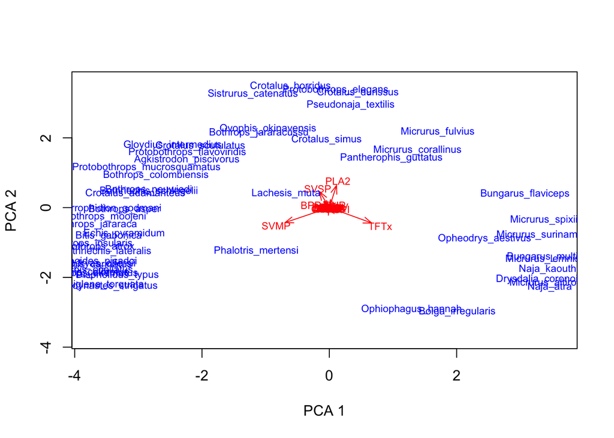

```r
#PC1 and PC2
plot(scores[,1], scores[,2], xlab="PCA 1", ylab="PCA 2",
     type="n", xlim=c(min(scores[,1:2]), max(scores[,1:2])),
     ylim=c(min(scores[,1:2]), max(scores[,1:2])))
arrows(0,0,evectors[,1],evectors[,2], length=0.1,
       angle=20, col="red")
text(evectors[,1]*1.2,evectors[,2]*1.2,
     rownames(evectors), col="red", cex=0.7)
text(scores[,1],scores[,2], rownames(scores), col="blue",
     cex=0.7)
```

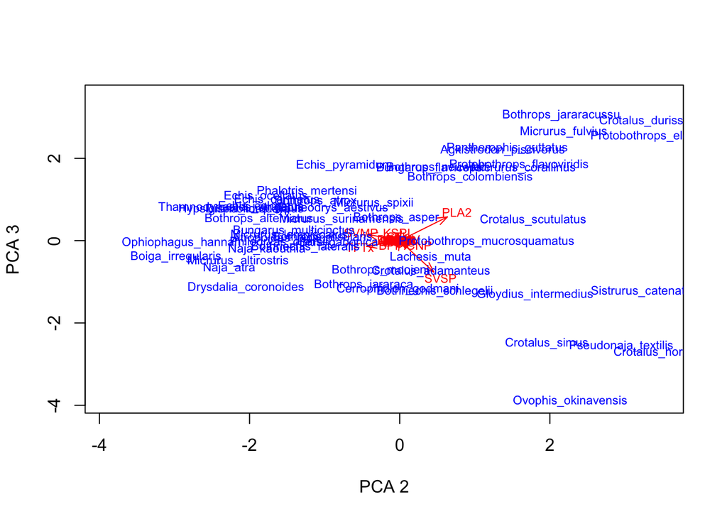

```r
#PC3 and PC4
plot(scores[,2], scores[,3], xlab="PCA 2", ylab="PCA 3",
     type="n", xlim=c(min(scores[,2:3]), max(scores[,2:3])),
     ylim=c(min(scores[,2:3]), max(scores[,2:3])))
arrows(0,0,evectors[,2],evectors[,3], length=0.1,
       angle=20, col="red")
text(evectors[,2]*1.2,evectors[,3]*1.2,
     rownames(evectors), col="red", cex=0.7)
text(scores[,2],scores[,3], rownames(scores), col="blue",
     cex=0.7)
```

The four major toxins still contribute the largest variation even when considering all 25 toxins. Species also cluster in a similar manner as in the phylomorphopsace estimated using the phylogenetic mixed model with 10 toxins.

[figure not shown]

```r
#scores for first two principal components were used as input for surface
dat <- scores

tree <- read.nexus("/Users/agneesh-barua/Dropbox (OIST)/R Training/Final_tree.nex")

tree <-nameNodes(tree)
olist <-convertTreeData(tree,dat[,])
otree <-olist[[1]]; odata<-olist[[2]]

#Forwards phase of SURFACE
fwd <- surfaceForward(otree, odata, aic_threshold = 0, exclude = 0, verbose = F, plotaic = T)
k<-length(fwd)
fsum <-surfaceSummary(fwd)

#Backward phase of SURFACE
bwd <- surfaceBackward(otree, odata, starting_model = fwd[[k]], aic_threshold = 0, only_best = T,verbose = F,plotaic = T)

bsum<- surfaceSummary(bwd)
kk<-length(bwd)
```

```r
fsum <-surfaceSummary(fwd)
k<-length(fwd)
fsum$aics
```

```
##        1        2        3        4        5        6        7        8
## 388.9473 384.3271 381.7628 365.6792 359.2225 354.8687 351.6153 344.9119
##        9       10       11       12       13
## 338.7551 333.7407 333.2429 330.4191 326.9997
```

```r
bsum<- surfaceSummary(bwd)
kk<-length(bwd)
bsum$aics
```

```
##        1        2        3        4        5        6
## 326.9997 315.7607 305.5269 296.0253 290.5120 287.1122
```

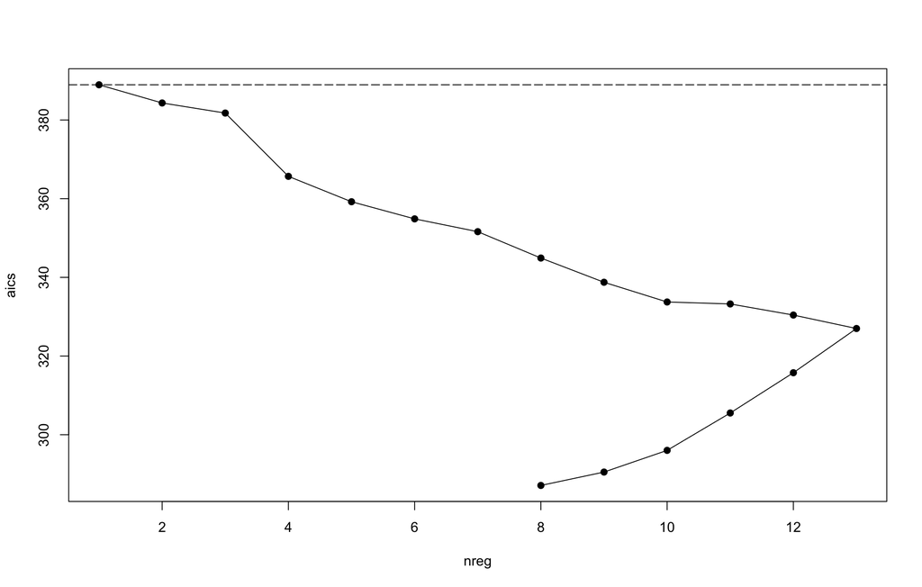

Improvement of AIC from forward to backward phase

```r
#Improvement of AIC
surfaceAICPlot(fwd, bwd)
```

```r
bsum$alpha
```

```
##      PC1      PC2
## 3.456154 5.906914
```

```r
bsum$sigma_squared
```

```
##      PC1      PC2
## 1.291952 8.218544
```

```r
bsum$theta
```

```
##           PC1        PC2
## a -3.43579728 -1.5843617
## b  0.04006913  2.9137392
## c  3.30431800 -1.2624050
## d  1.61842675 -1.2872125
## g -1.82535733  1.5725406
## h  1.48673108  1.8528375
## i -3.27051223 -0.4550448
## k -1.10858239 -1.1965927
```

```r
bsum$n_regimes
```

```
##              k         kprime         deltak              c    kprime_conv
##             13              8              5              9              4
## kprime_nonconv
##              4
```

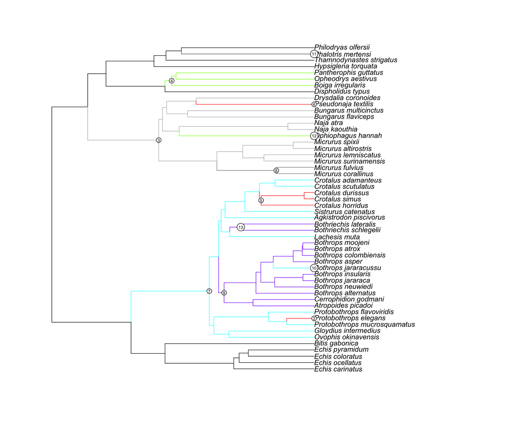

Default SURFACE tree plot showing convergence of coloured regimes

```r
#Convergence tree
tree <- read.nexus("/Users/agneesh-barua/Dropbox (OIST)/R Training/Final_tree.nex")
surfaceTreePlot(tree, bwd[[kk]], labelshifts = T, convcol = T)
```

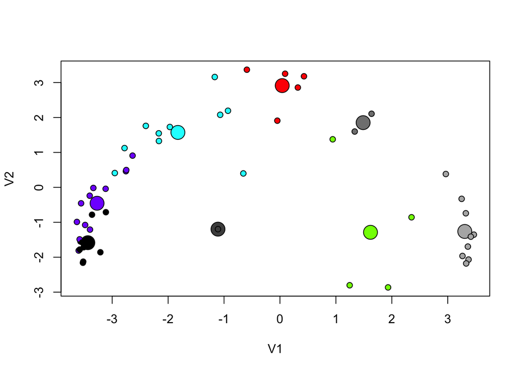

```r
surfaceTraitPlot(dat, bwd[[kk]],whattraits = c(1,2), convcol = T)
```

```r
#Simulating surface
#The following line of code was run in run 500 times to obtain a null distribution

newsim<- surfaceSimulate(tree, type = "hansen-fit", hansenfit = fwd[[k]]$fit, shifts = fwd[[k]]$savedshifts, sample_optima = T)

#Running analysis on simulated data
newout<-runSurface(tree, newsim$data, only_best = T)
newsum<-surfaceSummary(newout$bwd)
regimes<-newsum$n_regimes
regimes
```

8

4

8

4

4

13

10

3

6

3

7

12

10

2

4

2

8

12

10

2

3

1

9

11

7

4

6

2

5

12

8

4

7

3

5

12

9

3

5

2

7

12

9

3

6

3

6

11

8

3

5

2

6

11

9

2

4

2

7

12

8

4

7

3

5

11

8

3

6

3

5

6

5

1

2

1

4

12

9

3

5

2

7

12

7

5

9

4

3

10

7

3

6

3

4

11

8

3

5

2

6

11

7

4

7

3

4

12

9

3

5

2

7

10

7

3

6

3

4

11

9

2

4

2

7

12

10

2

4

2

8

11

6

5

8

3

3

9

7

2

3

1

6

12

10

2

4

2

8

11

6

5

8

3

3

9

6

3

5

2

4

8

6

2

4

2

4

10

7

3

6

3

4

11

9

2

4

2

7

8

7

1

2

1

6

10

7

3

6

3

4

12

7

5

9

4

3

8

5

3

5

2

3

12

8

4

7

3

5

10

8

2

3

1

7

13

11

2

4

2

9

10

7

3

5

2

5

12

8

4

7

3

5

12

9

3

5

2

7

13

8

5

8

3

5

10

8

2

4

2

6

12

8

4

8

4

4

11

8

3

6

3

5

11

8

3

6

3

5

13

8

5

9

4

4

11

8

3

6

3

5

13

8

5

8

3

5

9

7

2

4

2

5

11

7

4

7

3

4

9

8

1

2

1

7

9

8

1

2

1

7

12

7

5

9

4

3

11

7

4

8

4

3

12

6

6

10

4

2

9

7

2

3

1

6

12

8

4

8

4

4

12

8

4

7

3

5

11

9

2

4

2

7

11

9

2

4

2

7

9

6

3

5

2

4

9

9

0

0

0

9

11

9

2

4

2

7

10

7

3

6

3

4

11

8

3

6

3

5

13

9

4

7

3

6

13

8

5

9

4

4

8

6

2

4

2

4

13

8

5

7

2

6

12

9

3

6

3

6

12

8

4

7

3

5

10

8

2

3

1

7

8

8

0

0

0

8

12

6

6

9

3

3

9

6

3

6

3

3

11

8

3

5

2

6

12

7

5

9

4

3

11

7

4

7

3

4

11

10

1

2

1

9

10

9

1

2

1

8

10

7

3

5

2

5

11

7

4

7

3

4

10

6

4

8

4

2

11

8

3

5

2

6

13

10

3

6

3

7

8

4

4

7

3

1

11

7

4

7

3

4

12

8

4

7

3

5

11

8

3

5

2

6

10

7

3

5

2

5

13

10

3

6

3

7

9

7

2

4

2

5

10

7

3

6

3

4

11

8

3

6

3

5

11

8

3

5

2

6

12

9

3

6

3

6

11

7

4

7

3

4

12

7

5

9

4

3

7

5

2

4

2

3

12

8

4

8

4

4

12

8

4

7

3

5

10

7

3

5

2

5

11

10

1

2

1

9

11

8

3

5

2

6

9

6

3

6

3

3

10

8

2

4

2

6

11

8

3

6

3

5

12

8

4

8

4

4

12

8

4

7

3

5

11

8

3

5

2

6

11

9

2

3

1

8

11

6

5

8

3

3

10

7

3

5

2

5

12

9

3

5

2

7

13

7

6

8

2

5

11

7

4

8

4

3

10

6

4

7

3

3

10

8

2

4

2

6

12

9

3

5

2

7

9

7

2

4

2

5

12

7

5

9

4

3

13

9

4

8

4

5

12

6

6

8

2

4

11

7

4

7

3

4

12

8

4

8

4

4

12

9

3

6

3

6

10

7

3

5

2

5

12

9

3

6

3

6

11

7

4

8

4

3

11

7

4

7

3

4

10

5

5

8

3

2

13

8

5

10

5

3

13

10

3

5

2

8

13

8

5

8

3

5

8

6

2

4

2

4

12

9

3

5

2

7

9

6

3

5

2

4

11

6

5

7

2

4

11

8

3

6

3

5

12

7

5

10

5

2

12

6

6

10

4

2

11

9

2

4

2

7

9

6

3

6

3

3

12

9

3

6

3

6

12

9

3

5

2

7

10

8

2

4

2

6

9

6

3

5

2

4

11

8

3

6

3

5

13

8

5

8

3

5

13

8

5

8

3

5

12

7

5

9

4

3

13

8

5

8

3

5

12

9

3

6

3

6

11

7

4

6

2

5

10

6

4

7

3

3

12

7

5

9

4

3

15

9

6

10

4

5

12

9

3

6

3

6

13

10

3

6

3

7

11

9

2

4

2

7

12

8

4

6

2

6

12

8

4

7

3

5

9

7

2

4

2

5

13

7

6

9

3

4

12

10

2

4

2

8

12

8

4

6

2

6

13

9

4

8

4

5

11

7

4

7

3

4

10

6

4

7

3

3

9

7

2

4

2

5

10

5

5

6

1

4

12

8

4

7

3

5

13

8

5

10

5

3

11

8

3

6

3

5

11

9

2

4

2

7

11

7

4

6

2

5

12

9

3

6

3

6

10

7

3

5

2

5

12

8

4

7

3

5

11

8

3

5

2

6

14

8

6

11

5

3

12

9

3

4

1

8

9

5

4

7

3

2

11

6

5

9

4

2

11

8

3

5

2

6

12

9

3

5

2

7

11

7

4

7

3

4

12

11

1

2

1

10

13

10

3

6

3

7

12

8

4

8

4

4

12

9

3

6

3

6

11

9

2

4

2

7

10

8

2

4

2

6

13

8

5

10

5

3

10

6

4

7

3

3

12

7

5

10

5

2

13

8

5

10

5

3

12

6

6

11

5

1

12

10

2

4

2

8

13

8

5

9

4

4

12

10

2

4

2

8

13

9

4

7

3

6

11

9

2

4

2

7

10

8

2

4

2

6

11

7

4

7

3

4

11

8

3

6

3

5

9

5

4

7

3

2

12

9

3

5

2

7

8

4

4

7

3

1

12

8

4

8

4

4

12

10

2

4

2

8

11

8

3

5

2

6

12

9

3

5

2

7

9

7

2

4

2

5

12

7

5

7

2

5

13

9

4

7

3

6

12

7

5

8

3

4

11

7

4

7

3

4

11

9

2

4

2

7

11

7

4

7

3

4

12

8

4

7

3

5

12

8

4

7

3

5

10

7

3

6

3

4

8

6

2

4

2

4

12

7

5

8

3

4

12

9

3

5

2

7

10

9

1

2

1

8

13

9

4

7

3

6

10

6

4

7

3

3

9

6

3

6

3

3

12

9

3

6

3

6

11

7

4

7

3

4

12

9

3

4

1

8

11

8

3

6

3

5

11

7

4

6

2

5

12

7

5

9

4

3

10

6

4

7

3

3

11

7

4

7

3

4

13

9

4

7

3

6

9

7

2

4

2

5

11

9

2

4

2

7

10

8

2

4

2

6

13

7

6

9

3

4

10

7

3

6

3

4

13

10

3

6

3

7

11

8

3

6

3

5

12

8

4

8

4

4

9

8

1

2

1

7

11

5

6

10

4

1

13

7

6

10

4

3

10

6

4

6

2

4

13

10

3

6

3

7

11

8

3

5

2

6

9

7

2

4

2

5

10

7

3

5

2

5

12

7

5

7

2

5

12

9

3

6

3

6

11

7

4

7

3

4

10

8

2

4

2

6

13

7

6

10

4

3

13

9

4

7

3

6

13

7

6

10

4

3

11

8

3

6

3

5

12

7

5

9

4

3

12

8

4

8

4

4

11

7

4

7

3

4

13

7

6

10

4

3

8

6

2

4

2

4

11

8

3

5

2

6

11

7

4

6

2

5

11

8

3

6

3

5

9

7

2

4

2

5

10

9

1

2

1

8

13

10

3

6

3

7

10

9

1

2

1

8

10

6

4

7

3

3

10

8

2

4

2

6

12

7

5

9

4

3

10

9

1

2

1

8

13

11

2

4

2

9

13

9

4

8

4

5

13

9

4

7

3

6

12

8

4

7

3

5

12

8

4

5

1

7

12

7

5

9

4

3

8

5

3

6

3

2

13

9

4

7

3

6

13

9

4

8

4

5

11

8

3

6

3

5

9

6

3

5

2

4

13

10

3

6

3

7

13

9

4

7

3

6

12

8

4

7

3

5

11

7

4

7

3

4

11

5

6

9

3

2

13

9

4

7

3

6

9

7

2

4

2

5

13

10

3

6

3

7

11

8

3

6

3

5

12

7

5

8

3

4

13

7

6

12

6

1

11

8

3

6

3

5

9

7

2

4

2

5

13

10

3

6

3

7

13

8

5

8

3

5

8

5

3

5

2

3

12

8

4

8

4

4

10

7

3

4

1

6

9

7

2

3

1

6

11

8

3

6

3

5

11

8

3

6

3

5

12

8

4

7

3

5

11

6

5

9

4

2

12

8

4

7

3

5

8

6

2

4

2

4

13

9

4

7

3

6

11

8

3

5

2

6

13

8

5

8

3

5

11

5

6

10

4

1

12

7

5

8

3

4

12

9

3

5

2

7

8

6

2

4

2

4

11

7

4

6

2

5

11

8

3

6

3

5

13

7

6

11

5

2

11

6

5

7

2

4

12

10

2

4

2

8

10

6

4

7

3

3

13

9

4

7

3

6

8

7

1

2

1

6

11

7

4

6

2

5

7

7

0

0

0

7

10

7

3

6

3

4

12

8

4

8

4

4

12

10

2

4

2

8

13

8

5

9

4

4

9

7

2

4

2

5

12

10

2

4

2

8

8

5

3

6

3

2

10

6

4

8

4

2

10

8

2

3

1

7

14

8

6

11

5

3

11

9

2

4

2

7

12

8

4

7

3

5

12

10

2

4

2

8

12

7

5

9

4

3

12

7

5

9

4

3

11

7

4

8

4

3

13

8

5

8

3

5

12

10

2

4

2

8

12

9

3

6

3

6

9

7

2

4

2

5

14

8

6

11

5

3

12

8

4

7

3

5

12

7

5

8

3

4

12

9

3

6

3

6

10

8

2

4

2

6

13

10

3

6

3

7

10

7

3

5

2

5

11

8

3

5

2

6

13

10

3

5

2

8

12

7

5

9

4

3

15

8

7

12

5

3

13

10

3

6

3

7

11

7

4

8

4

3

13

8

5

8

3

5

10

6

4

7

3

3

13

9

4

7

3

6

11

8

3

6

3

5

9

7

2

4

2

5

9

7

2

4

2

5

10

9

1

2

1

8

10

6

4

8

4

2

13

9

4

7

3

6

12

7

5

9

4

3

12

10

2

4

2

8

9

7

2

3

1

6

11

8

3

5

2

6

11

8

3

5

2

6

10

8

2

4

2

6

12

7

5

8

3

4

12

9

3

6

3

6

12

8

4

8

4

4

13

11

2

4

2

9

11

7

4

7

3

4

11

6

5

8

3

3

12

8

4

8

4

4

12

7

5

9

4

3

9

6

3

6

3

3

14

9

5

9

4

5

11

8

3

6

3

5

13

10

3

6

3

7

9

6

3

5

2

4

10

8

2

3

1

7

12

9

3

6

3

6

13

8

5

9

4

4

13

8

5

9

4

4

12

10

2

4

2

8

12

8

4

7

3

5

13

10

3

6

3

7

11

9

2

3

1

8

12

8

4

7

3

5

11

8

3

6

3

5

11

6

5

7

2

4

12

6

6

9

3

3

12

10

2

4

2

8

12

6

6

11

5

1

6

5

1

2

1

4

10

6

4

8

4

2

9

5

4

6

2

3

13

10

3

5

2

8

13

9

4

7

3

6

10

7

3

6

3

4

13

9

4

6

2

7

11

8

3

5

2

6

12

8

4

8

4

4

12

9

3

6

3

6

12

8

4

8

4

4

12

8

4

8

4

4

11

10

1

2

1

9

12

9

3

6

3

6

13

9

4

7

3

6

11

8

3

6

3

5

14

8

6

12

6

2

12

8

4

7

3

5

12

7

5

9

4

3

9

7

2

4

2

5

12

6

6

9

3

3

12

8

4

8

4

4

12

7

5

10

5

2

9

6

3

5

2

4

12

9

3

6

3

6

12

8

4

7

3

5

11

8

3

6

3

5

12

7

5

9

4

3

11

8

3

6

3

5

11

8

3

6

3

5

10

8

2

4

2

6

10

6

4

7

3

3

11

7

4

8

4

3

12

7

5

8

3

4

9

6

3

6

3

3

11

7

4

7

3

4

10

7

3

5

2

5

12

8

4

6

2

6

12

7

5

10

5

2

11

9

2

4

2

7

13

9

4

7

3

6

12

9

3

5

2

7

12

10

2

3

1

9

12

8

4

8

4

4

12

6

6

11

5

1

12

9

3

5

2

7

11

9

2

4

2

7

11

6

5

9

4

2

13

9

4

8

4

5

8

6

2

4

2

4

11

8

3

6

3

5

10

7

3

5

2

5

7

6

1

2

1

5

10

7

3

4

1

6

10

7

3

5

2

5

9

6

3

5

2

4

11

7

4

8

4

3

11

6

5

8

3

3

12

9

3

5

2

7

11

10

1

2

1

9

12

7

5

9

4

3

12

6

6

10

4

2

11

8

3

6

3

5

12

8

4

7

3

5

11

9

2

4

2

7

[figure not shown]